# Hospital Admissions

Onesmas Ngugi

April 4, 2018

# INTRODUCTION

The Statewide Planning and Research Cooperative System (SPARCS) Inpatient De-identified File contains discharge level detail on patient characteristics, diagnoses, treatments, services, and charges. This data file contains basic record level detail for the discharge. The de-identified data file does not contain data that is protected health information (PHI) under HIPAA. The health information is not individually identifiable; all data elements considered identifiable have been redacted. For example, the direct identifiers regarding a date have the day and month portion of the date removed.

A few questions that might be interesting to help explore the data. 1. What affects hospital length of stay? Type of admission, patient disposition, emergency department indicator etc. 2. Are costs for similar procedures different depending in hospital area. 3. How ethnicity or race affect birth weight. 4. Costs over time. 5. Mortality rate vs severity of illness.

These are just a few ideas to help guide the exploratory analysis.

# Libraries and Data

Let’s explore the data.

The dataset has 1106830 records and 37 columns. The column names have spaces in them which makes working with them a bit cumbersome as quotes have to be used around column names everytime. We can rename the columns by replacing spaces with "_".

## Data Issues

1. Column names have spaces. Should be replaced with "_". Easier to work with.
2. I record has all entries missing. No explanation found. This record should be deleted.
3. From the data source, records relating to abortions have some information such as i.e Facility Name, Health Service Area, Hospital County Provider Licese Number etc. removed for privacy purposes. We can filter these data into a separate dataframe.
4. A few columns have a lot records missing. For example, `Other_Provider_License_Number` column has more than 94% of records missing. This column can be dropped as there is no way to impute the missing data. Other columns with missing data are;
- `Payment_Typology_3`
- `Payment_typology_2`
- `Operating_Provider_License_Number`
- `Length_of_Stay`
5. Zip codes have last two digits removed for privacy purposes.

### Fixes.

1. Replace spaces in column names with "_".
2. Drop row with missing info. Identified by missing Facility_Id.
3. Remove abortion-related records.

```
## # A tibble: 0 x 36
## # ... with 36 variables: Health_Service_Area <chr>, Hospital_County <chr>,
## #   Operating_Certificate_Number <chr>, Facility_Id <int>,
## #   Facility_Name <chr>, Age_Group <chr>, `Zip_Code_-_3_digits` <chr>,
## #   Gender <chr>, Race <chr>, Ethnicity <chr>, Length_of_Stay <dbl>,
## #   Type_of_Admission <chr>, Patient_Disposition <chr>,
## #   Discharge_Year <int>, CCS_Diagnosis_Code <int>,
## #   CCS_Diagnosis_Description <chr>, CCS_Procedure_Code <int>,
## #   CCS_Procedure_Description <chr>, APR_DRG_Code <int>,
## #   APR_DRG_Description <chr>, APR_MDC_Code <int>,
## #   APR_MDC_Description <chr>, APR_Severity_of_Illness_Code <int>,
## #   APR_Severity_of_Illness_Description <chr>,
## #   APR_Risk_of_Mortality <chr>, APR_Medical_Surgical_Description <chr>,
## #   Payment_Typology_1 <chr>, Payment_Typology_2 <chr>,
## #   Payment_Typology_3 <chr>, Attending_Provider_License_Number <int>,
## #   Operating_Provider_License_Number <int>,
## #   Other_Provider_License_Number <int>, Birth_Weight <int>,
## #   Emergency_Department_Indicator <chr>, Total_Charges <dbl>,
## #   Total_Costs <dbl>
```

```
## Observations: 353
## Variables: 37
## $ Health_Service_Area                 <chr> NA, NA, NA, NA, NA, NA, NA...
## $ Hospital_County                     <chr> NA, NA, NA, NA, NA, NA, NA...
## $ Operating_Certificate_Number        <chr> NA, NA, NA, NA, NA, NA, NA...
## $ Facility_Id                         <int> NA, NA, NA, NA, NA, NA, NA...
## $ Facility_Name                       <chr> "Abortion Record - Facilit...
## $ Age_Group                           <chr> "18 to 29", "30 to 49", "1...
## $ `Zip_Code_-_3_digits`               <chr> NA, NA, NA, NA, NA, NA, NA...
## $ Gender                              <chr> "F", "F", "F", "F", "F", "...
## $ Race                                <chr> "Multi-racial", "White", "...
## $ Ethnicity                           <chr> "Not Span/Hispanic", "Not ...
## $ Length_of_Stay                      <dbl> 2, 1, 1, 2, 1, 1, 2, 1, 1,...
## $ Type_of_Admission                   <chr> "Emergency", "Emergency", ...
## $ Patient_Disposition                 <chr> "Home or Self Care", "Home...
```

[output cut: 24 more lines]

We can further clean the abortion_df to drop columns with NA’s but I will leave that for later when I need to use this dataframe.

```
## # A tibble: 6 x 36
##   Health_Service_~ Hospital_County Operating_Certi~ Facility_Id
##   <chr>            <chr>           <chr>                  <int>
## 1 Western NY       Allegany        0226700                   37
## 2 Western NY       Allegany        0226700                   37
## 3 Western NY       Allegany        0226700                   37
## 4 Western NY       Allegany        0226700                   37
## 5 Western NY       Allegany        0226700                   37
## 6 Western NY       Allegany        0226700                   37
## # ... with 32 more variables: Facility_Name <chr>, Age_Group <chr>,
## #   `Zip_Code_-_3_digits` <chr>, Gender <chr>, Race <chr>,
## #   Ethnicity <chr>, Length_of_Stay <dbl>, Type_of_Admission <chr>,
## #   Patient_Disposition <chr>, Discharge_Year <int>,
## #   CCS_Diagnosis_Code <int>, CCS_Diagnosis_Description <chr>,
## #   CCS_Procedure_Code <int>, CCS_Procedure_Description <chr>,
## #   APR_DRG_Code <int>, APR_DRG_Description <chr>, APR_MDC_Code <int>,
## #   APR_MDC_Description <chr>, APR_Severity_of_Illness_Code <int>,
## #   APR_Severity_of_Illness_Description <chr>,
## #   APR_Risk_of_Mortality <chr>, APR_Medical_Surgical_Description <chr>,
## #   Payment_Typology_1 <chr>, Payment_Typology_2 <chr>,
## #   Payment_Typology_3 <chr>, Attending_Provider_License_Number <int>,
## #   Operating_Provider_License_Number <int>,
## #   Other_Provider_License_Number <int>, Birth_Weight <int>,
## #   Emergency_Department_Indicator <chr>, Total_Charges <dbl>,
## #   Total_Costs <dbl>
```

## Explore Missing Data

Let’s look at which variables have missing data. Visualizations can be a good way to quickly communicate results to an audience. Below, I have calculated the percentage of missing data for each variable. Most variables have very few missing data.

I used the `missmap` function from the [Amelia](https://cran.r-project.org/web/packages/Amelia/vignettes/amelia.pdf) package to visualize missing data.

```
##       Other_Provider_License_Number                  Payment_Typology_3
##                        94.571352857                        75.773230842
##                  Payment_Typology_2   Operating_Provider_License_Number
##                        41.274703727                        36.996960167
##                      Length_of_Stay                 Zip_Code_-_3_digits
##                         0.073440763                         0.013476199
## APR_Severity_of_Illness_Description               APR_Risk_of_Mortality
##                         0.003708216                         0.003708216
##                 Health_Service_Area                     Hospital_County
##                         0.000000000                         0.000000000
##        Operating_Certificate_Number                         Facility_Id
##                         0.000000000                         0.000000000
##                       Facility_Name                           Age_Group
##                         0.000000000                         0.000000000
##                              Gender                                Race
##                         0.000000000                         0.000000000
##                           Ethnicity                   Type_of_Admission
##                         0.000000000                         0.000000000
##                 Patient_Disposition                      Discharge_Year
##                         0.000000000                         0.000000000
##                  CCS_Diagnosis_Code           CCS_Diagnosis_Description
##                         0.000000000                         0.000000000
##                  CCS_Procedure_Code           CCS_Procedure_Description
##                         0.000000000                         0.000000000
##                        APR_DRG_Code                 APR_DRG_Description
##                         0.000000000                         0.000000000
##                        APR_MDC_Code                 APR_MDC_Description
##                         0.000000000                         0.000000000
##        APR_Severity_of_Illness_Code    APR_Medical_Surgical_Description
##                         0.000000000                         0.000000000
##                  Payment_Typology_1   Attending_Provider_License_Number
##                         0.000000000                         0.000000000
##                        Birth_Weight      Emergency_Department_Indicator
##                         0.000000000                         0.000000000
##                       Total_Charges                         Total_Costs
##                         0.000000000                         0.000000000
```

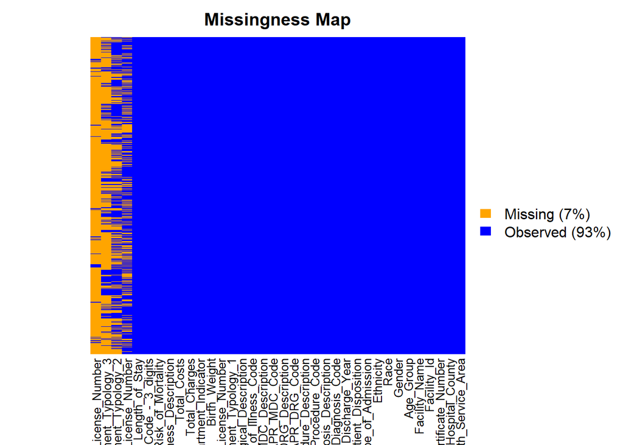

As seen above, most of the columns do not have any missing data. However, there are four columns that are missing a lot of data. Depending on whether the column is useful for analysis, I can drop it or figure out how to deal with the missing data, for example, by filling with mean or something similar.

# Univariate Analysis

In this section, I will explore individual variables to for such attributes as distibution, outliers etc. I will rely on histograms, boxplots and density plots fot visualiztions.

### Length of Stay

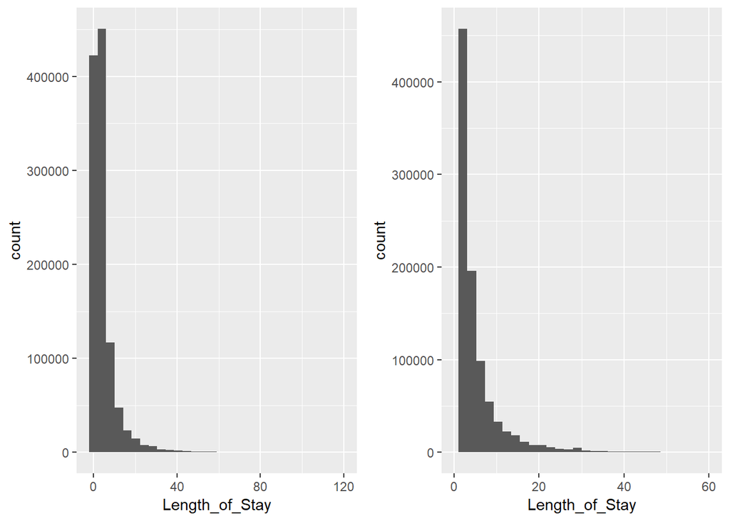

Boxplots are a good way to visualize summaries of a variable including mean, 1st and 3rd quartiles and any outliers in the data. One limit with traditional boxplots, however, poor visualization if the data set is too large with too many outliers.

A better way to draw boxplots for large data sets is using the letter value plots that better estimate tail behavior. From Hadley Wickham’s [Letter-value plots: Boxplots for large data](http://vita.had.co.nz/papers/letter-value-plot.html): >The letter-value plot …: (1) it conveys more detailed information in the >tails using letter values, but only to the depths where the letter values are >reliable estimates of their corresponding quantiles and (2) {“}outliers{”} are >labeled as those observations beyond the most extreme letter value.

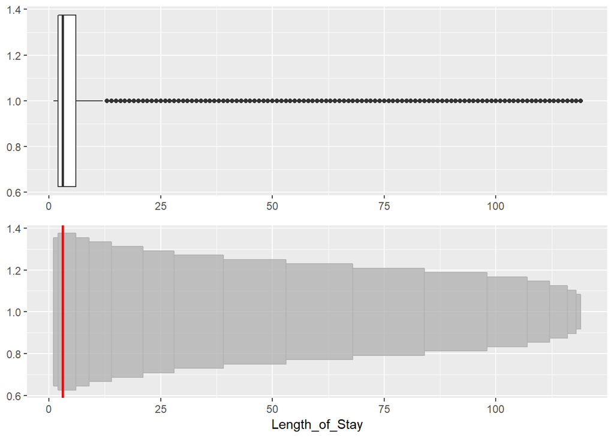

```
##    Min. 1st Qu.  Median    Mean 3rd Qu.    Max.    NA's
##   1.000   2.000   3.000   5.241   6.000 119.000     812
```

The plots above show that `Length_of_Stay` is right-skewed. Most of the values are less than 15 but there are also a lot of outliers as shown by the boxplot.

The summary shows the avergae length of stay is 5.2 days while the standard deviation is 7.1546583.

```
## [1] "Simple function for displaying histograms of numerical variables."
```

```
## [1] "... arg for additional arguments when necessary."
```

### Total Costs

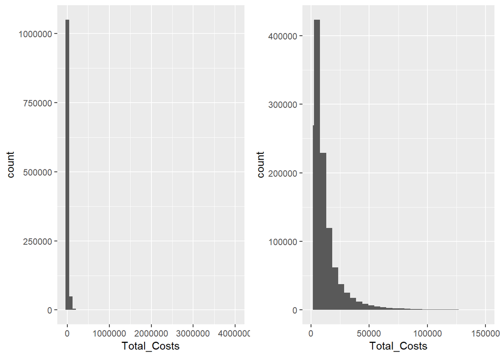

```
##    Min. 1st Qu.  Median    Mean 3rd Qu.    Max.
##       0    4117    7726   13292   14492 3976997
```

The histogram on the left shows that the `Total_Cost` variable has extreme outliers that skew the plot heavily to the right.

On the right, I have excluded some some outliers using the scale_x_continuous function to make the histogram a bit more useful. However, the skeweness is still visible in the plot.

### Distribution of a few Discrete Variables

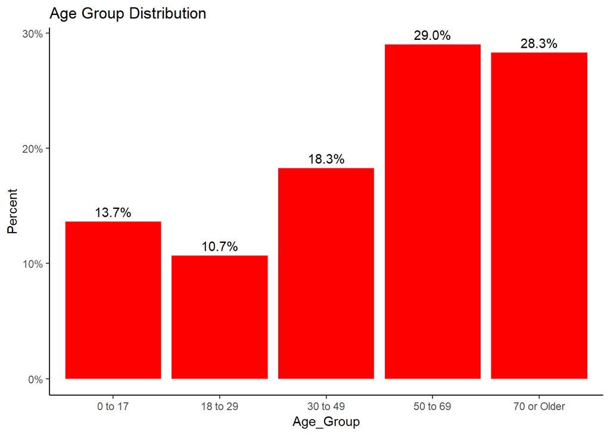

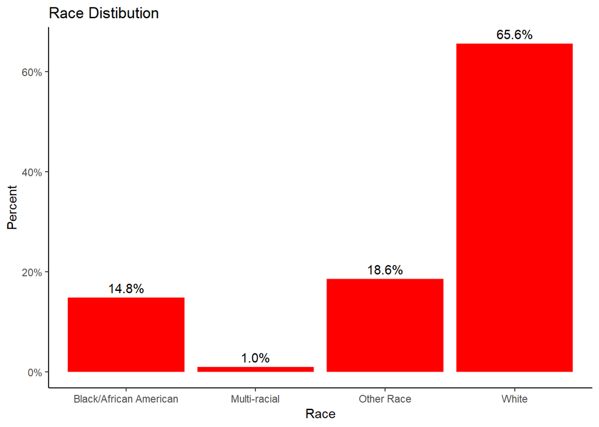

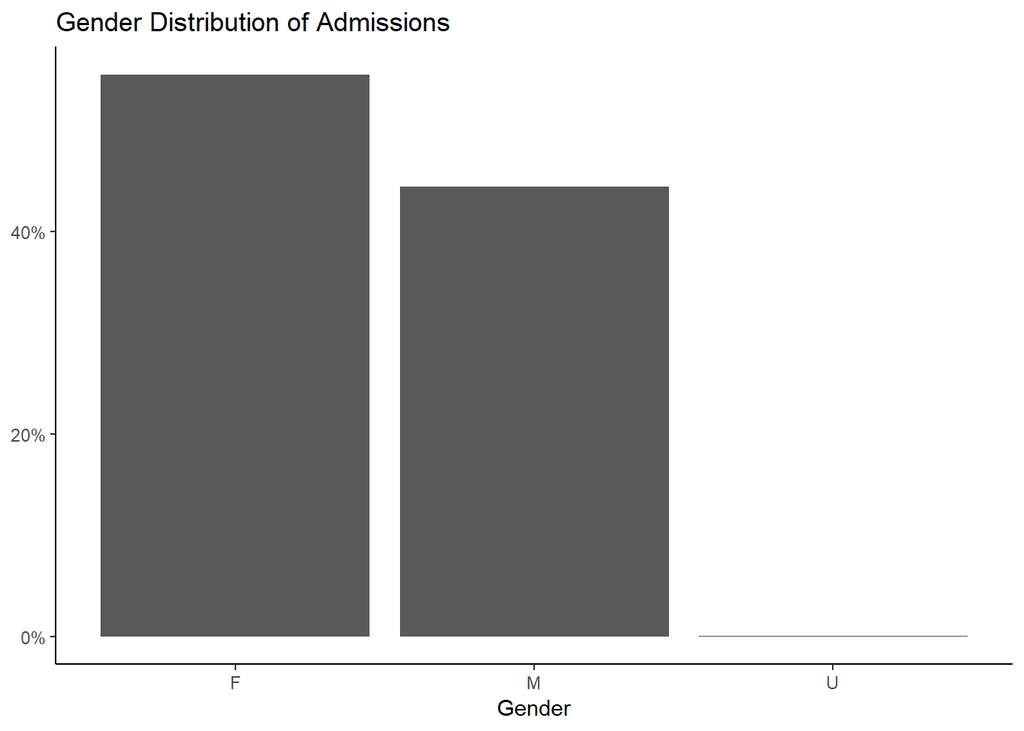

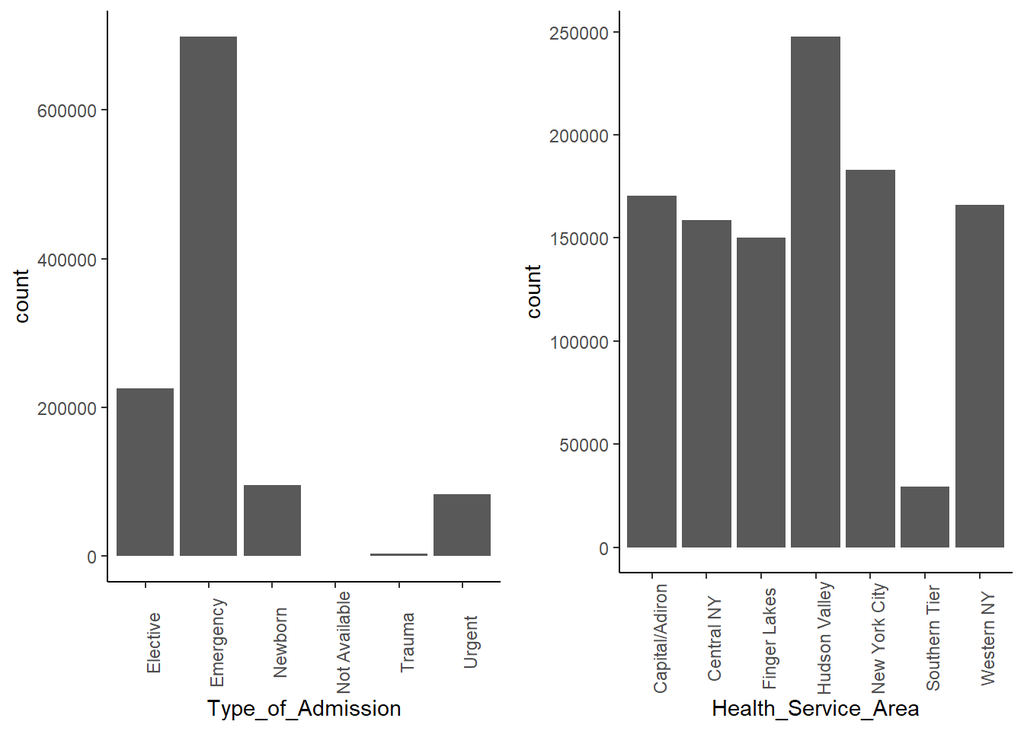

## Univariate Analysis

We can use different scale transformations to deal with outliers. Log transfomations are one way of to deal with right-skewed distributions.

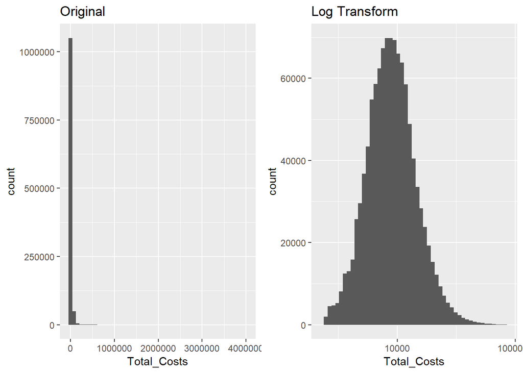

The transformed histogram of `Total_Costs` is normally distibuted.